# Analiza danych - projekt

```r
library(ggplot2)
library(plotly)
library(dplyr)

dane_used <- dane %>%
  filter(Condition == "Used") %>%
  mutate(
    cena_per_km = Price / Mileage_km,
    Production_year_group = case_when(
      Production_year <= 2000 ~ "Do 2000",
      Production_year <= 2010 ~ "2001-2010",
      TRUE ~ "Po 2010"
    )
  )

p <- ggplot(
  dane_used,
  aes(
    x = Production_year_group,
    y = cena_per_km,
    fill = Vehicle_brand,
    text = paste(
      "Marka:", Vehicle_brand,
      "<br>Rok (grupa):", Production_year_group,
      "<br>Cena/km:", round(cena_per_km, 2), "PLN"
    )
  )
) +
  geom_boxplot(outlier.shape = NA, alpha = 0.7) +
  facet_grid(~ Vehicle_brand, scales = "fixed") +
  coord_cartesian(ylim = c(0, 15)) +
  labs(
    title = "Zależność ceny za kilometr od roku produkcji samochodu używanego",
    x = "Grupa roku produkcji",
    y = "Cena za kilometr (PLN/km)",
    fill = "Marka samochodu"
  ) +
  scale_fill_manual(values = brand_colors) +
  theme_minimal() +
  theme(axis.text.x = element_text(angle = 45, hjust = 1))

ggplotly(p, tooltip = "text")
```

[interactive chart not shown]

```r
library(dplyr)
library(knitr)
library(kableExtra)
library(scales)

# Przygotowanie danych do tabeli H10
tab_h10 <- dane %>%
  filter(
    Condition == "Used",
    Vehicle_brand %in% c("BMW", "Mercedes-Benz"),
    !is.na(Price),
    !is.na(Mileage_km),
    Mileage_km > 0
  ) %>%
  mutate(
    cena_per_km = Price / Mileage_km,
    Grupa_roku = case_when(
      Production_year <= 2000 ~ "Do 2000",
      Production_year > 2000 & Production_year <= 2010 ~ "2001-2010",
      Production_year > 2010 ~ "Po 2010"
    )
  ) %>%
  group_by(Vehicle_brand, Grupa_roku) %>%
  summarise(
    n = sum(!is.na(cena_per_km)),
    Srednia = mean(cena_per_km, na.rm = TRUE),
    Q1 = quantile(cena_per_km, 0.25, na.rm = TRUE),
    Mediana = median(cena_per_km, na.rm = TRUE),
    Q3 = quantile(cena_per_km, 0.75, na.rm = TRUE),
    .groups = "drop"
  ) %>%
  rename(Marka = Vehicle_brand) %>%
  arrange(Marka, Grupa_roku) %>%
  mutate(across(c(n, Srednia, Q1, Mediana, Q3), ~comma(round(.x, 2), big.mark = " ")))

# Render tabeli w stylu raportowym
tab_h10 %>%
  kable(
    "html",
    caption = "H10: Cena za kilometr samochodu używanego w zależności od grupy roku produkcji",
    align = "c",
    col.names = c("Marka", "Grupa roku produkcji", "Liczba", "Średnia", "Q1", "Mediana", "Q3")
  ) %>%
  kable_styling(
    full_width = FALSE,
    bootstrap_options = c("striped", "condensed", "hover")
  ) %>%
  row_spec(0, bold = TRUE, color = "white", background = "#2C3E50")
```

H10: Cena za kilometr samochodu używanego w zależności od grupy roku produkcji

| Marka | Grupa roku produkcji | Liczba | Średnia | Q1 | Mediana | Q3 |
| --- | --- | --- | --- | --- | --- | --- |
| BMW | 2001-2010 | 5 847 | 0.55 | 0.07 | 0.10 | 0.16 |
| BMW | Do 2000 | 749 | 273.66 | 0.03 | 0.05 | 0.12 |
| BMW | Po 2010 | 8 554 | 244.27 | 0.35 | 0.87 | 2.89 |
| Mercedes-Benz | 2001-2010 | 4 332 | 0.22 | 0.06 | 0.11 | 0.19 |
| Mercedes-Benz | Do 2000 | 1 332 | 26.43 | 0.04 | 0.11 | 0.32 |
| Mercedes-Benz | Po 2010 | 5 264 | 519.50 | 0.52 | 1.56 | 5.61 |

Wyniki dla „ceny za kilometr” pokazują bardzo wyraźny podział według rocznika: w obu markach najnowsze auta (Po 2010) mają zdecydowanie wyższą medianę ceny/km niż starsze grupy, co widać też na boxplotach jako przesunięcie rozkładu w górę. Dla BMW mediana rośnie z ok. 0.05–0.10 PLN/km w grupach „Do 2000” i „2001–2010” do ok. 0.87 PLN/km po 2010, a dla Mercedes-Benz z ok. 0.11 PLN/km do ok. 1.55 PLN/km.

Porównując marki w tej samej grupie rocznika, Mercedes-Benz jest droższy „na kilometr” w najnowszej grupie: po 2010 mediana to ok. 1.55 PLN/km wobec ok. 0.87 PLN/km w BMW, a także wyższy jest cały środek rozkładu (Q1–Q3). Dla roczników 2001–2010 mediany są bardzo zbliżone (ok. 0.10–0.11 PLN/km), co sugeruje, że różnice między markami najmocniej ujawniają się w segmencie nowszych aut.

Widać też silną prawostronną skośność „ceny/km” (szczególnie w grupach „Do 2000” i „Po 2010”), gdzie mediany są relatywnie niskie, ale średnie są wielokrotnie wyższe, co wynika z pojedynczych przypadków ekstremalnie wysokiej ceny/km (np. bardzo mały przebieg przy wysokiej cenie). Dlatego w tej hipotezie najbardziej miarodajne do porównań są mediana i kwartyle, które stabilnie pokazują wzrost ceny/km wraz z nowszym rokiem produkcji oraz przewagę Mercedesa w autach po 2010.

Hipoteza H11 (Cena a moc i lokalizacja – BMW vs Mercedes (województwa)) - kilka map

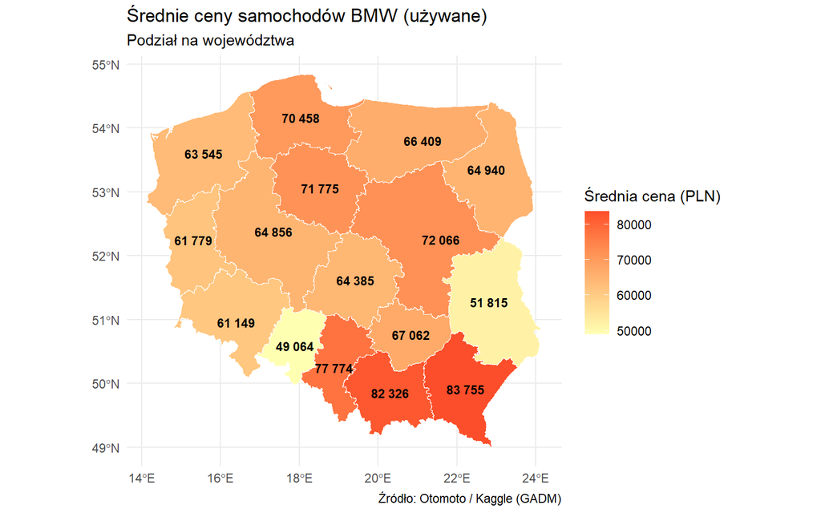

```r
# Pakiety --------------------------------------------------
library(ggplot2)
library(dplyr)
library(stringr)
library(sf)
library(geodata)
# Lista województw
wojewodztwa <- c(
  "dolnośląskie", "kujawsko-pomorskie", "lubelskie", "lubuskie",
  "łódzkie", "małopolskie", "mazowieckie", "opolskie",
  "podkarpackie", "podlaskie", "pomorskie", "śląskie",
  "świętokrzyskie", "warmińsko-mazurskie", "wielkopolskie", "zachodniopomorskie"
)

# Ekstrakcja województwa z lokalizacji oferty
dane_used <- dane_used %>%
  mutate(
    wojewodztwo = str_extract(
      str_to_lower(Offer_location),
      paste(wojewodztwa, collapse = "|")
    )
  ) %>%
  filter(!is.na(wojewodztwo))

# Agregacja średnich cen
ceny_woj <- dane_used %>%
  filter(Condition == "Used") %>%
  group_by(wojewodztwo, Vehicle_brand) %>%
  summarise(
    mean_price = mean(Price, na.rm = TRUE),
    n = n(),
    .groups = "drop"
  ) %>%
  filter(n >= 30)

# Granice województw
poland_sf <- gadm(
  country = "POL",
  level = 1,
  path = tempdir()
) %>%
  st_as_sf() %>%
  mutate(
    wojewodztwo = str_to_lower(NAME_1)
  )

# Połączenie danych z granicami
map_data <- poland_sf %>%
  left_join(ceny_woj, by = "wojewodztwo") %>%
  mutate(
    mean_price_label = ifelse(
      is.na(mean_price),
      NA,
      format(round(mean_price, 0), big.mark = " ")
    )
  )

# MAPA 1: BMW
ggplot(
  map_data %>% filter(Vehicle_brand == "BMW")
) +
  geom_sf(aes(fill = mean_price), color = "white") +
  geom_sf_text(
    aes(label = mean_price_label),
    size = 3,
    color = "black",
    fontface = "bold"
  ) +
  scale_fill_gradient(
    name = "Średnia cena (PLN)",
    low = "#FFFFB2",
    high = "#FC4E2A",
    na.value = "grey90"
  ) +
  labs(
    title = "Średnie ceny samochodów BMW (używane)",
    subtitle = "Podział na województwa",
    caption = "Źródło: Otomoto / Kaggle (GADM)",
    x = NULL,
    y = NULL
  ) +
  theme_minimal()
```

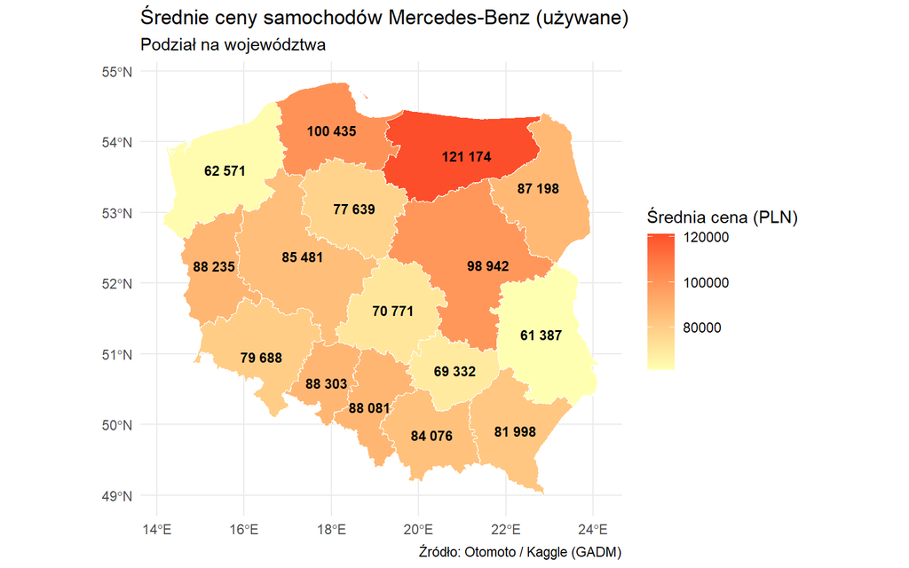

```r
# MAPA 2: Mercedes-Benz
ggplot(
  map_data %>% filter(Vehicle_brand == "Mercedes-Benz")
) +
  geom_sf(aes(fill = mean_price), color = "white") +
  geom_sf_text(
    aes(label = mean_price_label),
    size = 3,
    color = "black",
    fontface = "bold"
  ) +
  scale_fill_gradient(
    name = "Średnia cena (PLN)",
    low = "#FFFFB2",
    high = "#FC4E2A",
    na.value = "grey90"
  ) +
  labs(
    title = "Średnie ceny samochodów Mercedes-Benz (używane)",
    subtitle = "Podział na województwa",
    caption = "Źródło: Otomoto / Kaggle (GADM)",
    x = NULL,
    y = NULL
  ) +
  theme_minimal()
```

Średnie ceny aut używanych różnią się między województwami, a w wielu regionach Mercedes-Benz osiąga wyższe wartości niż BMW (np. dolnośląskie: ok. 80 tys. PLN vs ok. 61 tys. PLN). Na mapach widać więc, że poziom cen nie jest przestrzennie jednolity i zależy od regionu, co sugeruje zróżnicowanie „profilu” ofert w skali kraju.

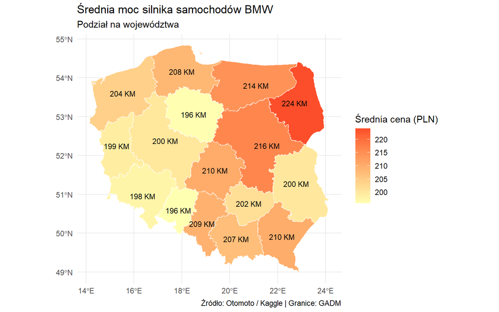

```r
# 1. Pakiety ------------------------------------------------
library(dplyr)
library(stringr)
library(sf)
library(ggplot2)
library(geodata)

# 2. Dane: używane BMW i Mercedes z mocą -------------------
dane_used <- dane %>%
  filter(
    Condition == "Used",
    Vehicle_brand %in% c("BMW", "Mercedes-Benz"),
    !is.na(Power_HP)
  )

# 3. Lista województw --------------------------------------
wojewodztwa <- c(
  "dolnośląskie", "kujawsko-pomorskie", "lubelskie", "lubuskie",
  "łódzkie", "małopolskie", "mazowieckie", "opolskie",
  "podkarpackie", "podlaskie", "pomorskie", "śląskie",
  "świętokrzyskie", "warmińsko-mazurskie", "wielkopolskie",
  "zachodniopomorskie"
)

# 4. Ekstrakcja województwa --------------------------------
dane_used <- dane_used %>%
  mutate(
    wojewodztwo = str_extract(
      str_to_lower(Offer_location),
      paste(wojewodztwa, collapse = "|")
    )
  ) %>%
  filter(!is.na(wojewodztwo))

# 5. Agregacja: średnia moc --------------------------------
power_woj <- dane_used %>%
  group_by(wojewodztwo, Vehicle_brand) %>%
  summarise(
    mean_power = mean(Power_HP, na.rm = TRUE),
    n = n(),
    .groups = "drop"
  ) %>%
  filter(n >= 30)

# 6. Granice województw ------------------------------------
poland_sf <- gadm(
  country = "POL",
  level = 1,
  path = tempdir()
) %>%
  st_as_sf() %>%
  mutate(
    wojewodztwo = str_to_lower(NAME_1)
  )

# 7. Połączenie z mapą -------------------------------------
map_data <- poland_sf %>%
  left_join(power_woj, by = "wojewodztwo") %>%
  mutate(
    mean_power_label = ifelse(
      is.na(mean_power),
      NA,
      paste0(round(mean_power, 0), " KM")
    )
  )

# 8. MAPA: BMW ----------------------------------------------
ggplot(
  map_data %>% filter(Vehicle_brand == "BMW")
) +
  geom_sf(aes(fill = mean_power), color = "white") +
  geom_sf_text(aes(label = mean_power_label), size = 3) +
  scale_fill_gradient(
    name = "Średnia cena (PLN)",
    low = "#FFFFB2",
    high = "#FC4E2A",
    na.value = "grey90"
  ) +
  labs(
    title = "Średnia moc silnika samochodów BMW",
    subtitle = "Podział na województwa",
    caption = "Źródło: Otomoto / Kaggle | Granice: GADM",
    x = NULL,
    y = NULL
  ) +
  theme_minimal()
```

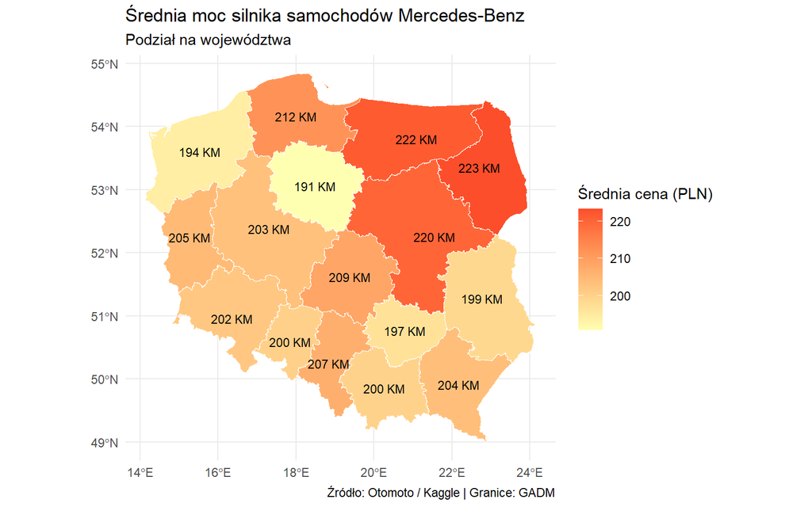

```r
# 9. MAPA: Mercedes-Benz -----------------------------------
ggplot(
  map_data %>% filter(Vehicle_brand == "Mercedes-Benz")
) +
  geom_sf(aes(fill = mean_power), color = "white") +
  geom_sf_text(aes(label = mean_power_label), size = 3) +
 scale_fill_gradient(
    name = "Średnia cena (PLN)",
    low = "#FFFFB2",
    high = "#FC4E2A",
    na.value = "grey90"
  ) +
  labs(
    title = "Średnia moc silnika samochodów Mercedes-Benz",
    subtitle = "Podział na województwa",
    caption = "Źródło: Otomoto / Kaggle | Granice: GADM",
    x = NULL,
    y = NULL
  ) +
  theme_minimal()
```

Mapy średniej mocy pokazują podobny regionalny wzorzec: województwa z wyższymi średnimi cenami często mają też wyższą przeciętną moc silnika (np. w dolnośląskim średnia moc jest wyższa dla Mercedes-Benz niż dla BMW: ok. 202 KM vs ok. 198 KM). Oznacza to, że w części regionów struktura ogłoszeń przesuwa się w stronę mocniejszych wersji, co naturalnie podnosi ogólny poziom ofert.

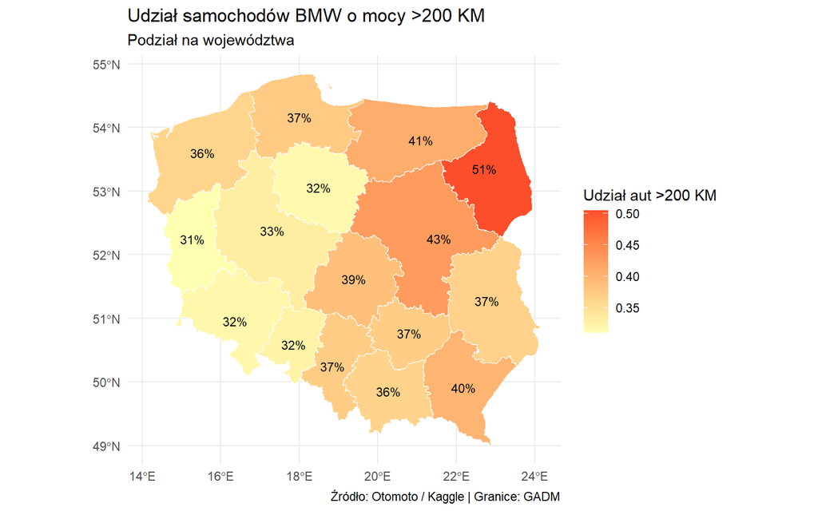

```r
############################################################
# H13 – Udział samochodów >200 KM
# Marki: BMW, Mercedes-Benz
# Poziom: WOJEWÓDZTWA (GADM level = 1)
############################################################

# 1. Pakiety ------------------------------------------------
library(dplyr)
library(stringr)
library(sf)
library(ggplot2)
library(geodata)

# 2. Dane wejściowe ----------------------------------------
dane_used <- dane %>%
  filter(
    Condition == "Used",
    Vehicle_brand %in% c("BMW", "Mercedes-Benz")
  )

# 3. Zmienna wysoka moc ------------------------------------
dane_used <- dane_used %>%
  filter(!is.na(Power_HP)) %>%
  mutate(
    High_power = Power_HP > 200
  )

# 4. Lista województw --------------------------------------
wojewodztwa <- c(
  "dolnośląskie", "kujawsko-pomorskie", "lubelskie", "lubuskie",
  "łódzkie", "małopolskie", "mazowieckie", "opolskie",
  "podkarpackie", "podlaskie", "pomorskie", "śląskie",
  "świętokrzyskie", "warmińsko-mazurskie", "wielkopolskie",
  "zachodniopomorskie"
)

# 5. Ekstrakcja województwa z lokalizacji -------------------
dane_used <- dane_used %>%
  mutate(
    wojewodztwo = str_extract(
      str_to_lower(Offer_location),
      paste(wojewodztwa, collapse = "|")
    )
  ) %>%
  filter(!is.na(wojewodztwo))

# 6. Agregacja: udział >200 KM ------------------------------
power_woj <- dane_used %>%
  group_by(wojewodztwo, Vehicle_brand) %>%
  summarise(
    share_high_power = mean(High_power, na.rm = TRUE),
    n = n(),
    .groups = "drop"
  ) %>%
  filter(n >= 30)

# 7. Granice WOJEWÓDZTW (GADM) ------------------------------
wojewodztwa_sf <- gadm(
  country = "POL",
  level = 1,
  path = tempdir()
) %>%
  st_as_sf() %>%
  mutate(
    wojewodztwo = str_to_lower(NAME_1)
  )

# 8. Połączenie danych z mapą -------------------------------
map_data <- wojewodztwa_sf %>%
  left_join(power_woj, by = "wojewodztwo")

library(ggrepel) # przydatne do lepszych etykiet na mapie
# 9. MAPA: BMW ----------------------------------------------
ggplot(
  map_data %>% filter(Vehicle_brand == "BMW")
) +
  geom_sf(aes(fill = share_high_power), color = "white") +
  geom_text(
    aes(label = scales::percent(share_high_power, accuracy = 1),
        geometry = geometry),
    stat = "sf_coordinates", size = 3
  ) +
  scale_fill_gradient(
    name = "Udział aut >200 KM",
    low = "#FFFFB2",
    high = "#FC4E2A",
    na.value = "grey90"
  ) +
  labs(
    title = "Udział samochodów BMW o mocy >200 KM",
    subtitle = "Podział na województwa",
    caption = "Źródło: Otomoto / Kaggle | Granice: GADM",
    x = NULL,
    y = NULL
  ) +
  theme_minimal()
```

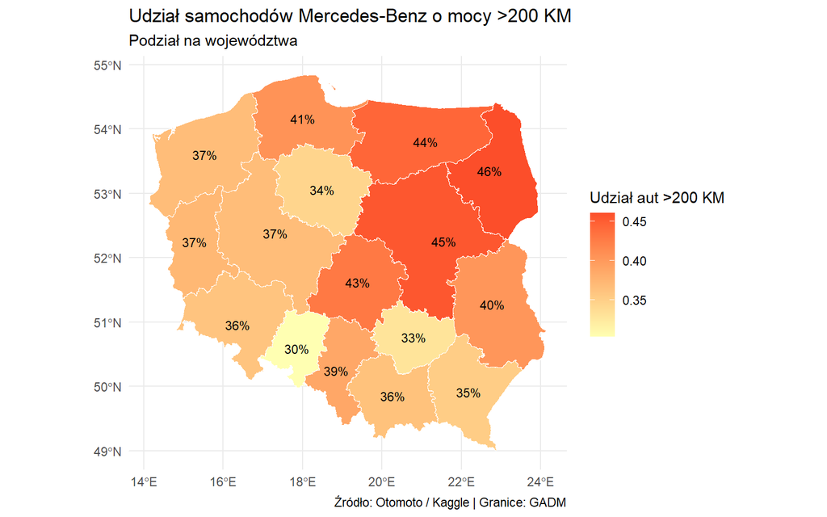

```r
# 10. MAPA: Mercedes-Benz -----------------------------------
ggplot(
  map_data %>% filter(Vehicle_brand == "Mercedes-Benz")
) +
  geom_sf(aes(fill = share_high_power), color = "white") +
  geom_text(
    aes(label = scales::percent(share_high_power, accuracy = 1),
        geometry = geometry),
    stat = "sf_coordinates", size = 3
  ) +
  scale_fill_gradient(
    name = "Udział aut >200 KM",
    low = "#FFFFB2",
    high = "#FC4E2A",
    na.value = "grey90"
  ) +
  labs(
    title = "Udział samochodów Mercedes-Benz o mocy >200 KM",
    subtitle = "Podział na województwa",
    caption = "Źródło: Otomoto / Kaggle | Granice: GADM",
    x = NULL,
    y = NULL
  ) +
  theme_minimal()
```

Udział aut o mocy powyżej 200 KM domyka ten obraz: różnice między województwami są widoczne i spójne kierunkowo dla obu marek. Najwyższe udziały występują w podlaskim (BMW ok. 50%, Mercedes-Benz ok. 46%), a najniższe odpowiednio w lubuskim (BMW ok. 31%) i opolskim (Mercedes-Benz ok. 30%), co pokazuje, że „mocny” segment rynku ma wyraźną koncentrację regionalną.

# 4. Analiza opisowa

## 4.1. Wykres korelacji

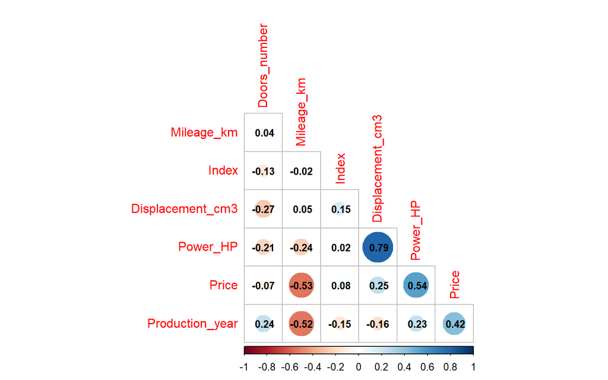

```r
library(dplyr)
library(corrplot)
dane_used <- dane %>% filter(Condition == "Used")
# wybór zmiennych numerycznych
num_cols <- dane_used %>%
  select_if(is.numeric)

# macierz korelacji (Pearson)
M <- cor(num_cols, use = "pairwise.complete.obs", method = "pearson")

# testy istotności korelacji
testRes <- cor.mtest(num_cols, conf.level = 0.95)

# wykres korelacji – wersja finalna
corrplot(
  M,
  p.mat = testRes$p,
  method = "circle",
  type = "lower",
  insig = "blank",
  addCoef.col = "black",
  number.cex = 0.8,
  order = "AOE",
  diag = FALSE
)
```

```r
library(dplyr)
library(car)
dane_used <- dane %>% filter(Condition == "Used")
# Model ANCOVA dla H1: Price ~ Vehicle_brand + Mileage_km + Production_year
model_h1 <- aov(
  Price ~ Vehicle_brand + Mileage_km + Production_year,
  data = dane_used
)
# Podsumowanie wyników ANCOVA
summary(model_h1)
```

```
##                    Df    Sum Sq   Mean Sq F value Pr(>F)
## Vehicle_brand       1 1.096e+12 1.096e+12   144.6 <2e-16 ***
## Mileage_km          1 8.270e+13 8.270e+13 10906.1 <2e-16 ***
## Production_year     1 9.524e+12 9.524e+12  1256.1 <2e-16 ***
## Residuals       26074 1.977e+14 7.583e+09
## ---
## Signif. codes:  0 '***' 0.001 '**' 0.01 '*' 0.05 '.' 0.1 ' ' 1
```

```r
#Zapisywanie wyniku za pomoca pakietu kable
library(knitr)
library(kableExtra)
ancova_table_h1 <- as.data.frame(summary(model_h1)[[1]])
ancova_table_h1 %>%
  kable(
    "html",
    caption = "Tabela wyników ANCOVA dla ceny w zależności od marki, wielkości przebiegu i roku produkcji",
    align = "c",
    col.names = c("Źródło", "Df", "Sum Sq", "Mean Sq", "F value", "Pr(>F)")
  ) %>%
  kable_styling(
    full_width = FALSE,
    bootstrap_options = c("striped", "condensed", "hover")
  ) %>%
  row_spec(0, bold = TRUE, color = "white", background = "#2C3E50")
```

Tabela wyników ANCOVA dla ceny w zależności od marki, wielkości przebiegu i roku produkcji

| Źródło | Df | Sum Sq | Mean Sq | F value | Pr(>F) |
| --- | --- | --- | --- | --- | --- |
| Vehicle_brand | 1 | 1.096415e+12 | 1.096415e+12 | 144.597 | 0 |
| Mileage_km | 1 | 8.269653e+13 | 8.269653e+13 | 10906.148 | 0 |
| Production_year | 1 | 9.524294e+12 | 9.524294e+12 | 1256.079 | 0 |
| Residuals | 26074 | 1.977077e+14 | 7.582560e+09 | NA | NA |

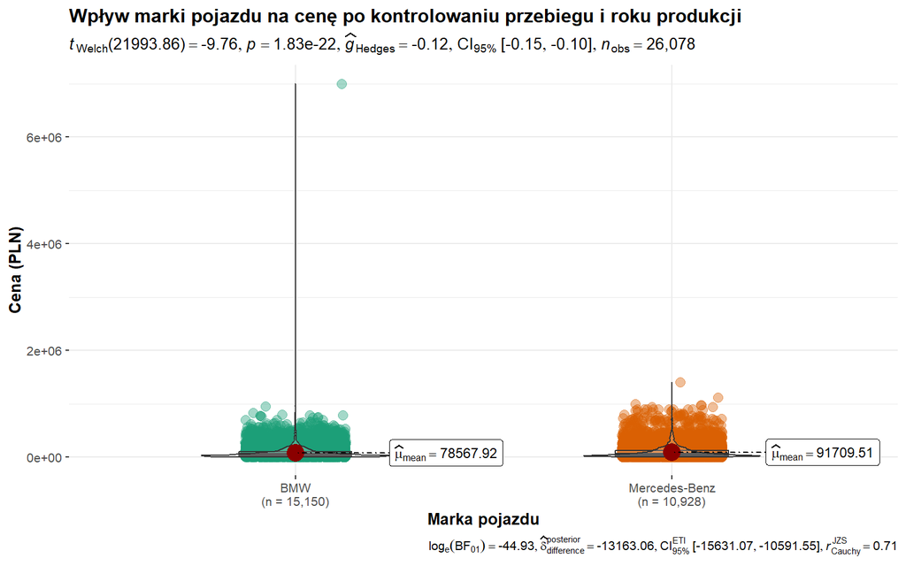

```r
#wykres z wykorzystaniem pakietu ggstatsplot
library(ggstatsplot)
ggstatsplot::ggbetweenstats(
  data = dane_used,
  x = Vehicle_brand,
  y = Price,
  covariate = c("Mileage_km", "Production_year"),
  title = "Wpływ marki pojazdu na cenę po kontrolowaniu przebiegu i roku produkcji",
  xlab = "Marka pojazdu",
  ylab = "Cena (PLN)"
)
```

Wyniki ANCOVA dla hipotezy H1 pokazują, że marka pojazdu (Vehicle_brand) ma istotny wpływ na cenę (Price) po kontrolowaniu przebiegu (Mileage_km) i roku produkcji (Production_year). Wartość p dla Vehicle_brand jest mniejsza niż 0.05, co pozwala odrzucić hipotezę zerową o braku różnic cen między markami po uwzględnieniu tych czynników kontrolnych. Oznacza to, że nawet po uwzględnieniu wpływu przebiegu i roku produkcji, marka samochodu pozostaje istotnym czynnikiem różnicującym ceny samochodów używanych.

## 5.2. ANOVA Price ~ Fuel_type + Transmission

```r
# H₀₁: brak wpływu Fuel_type na Price
# H₀₂: brak wpływu Transmission na Price
# H₀₃: brak interakcji Fuel_type × Transmission
# H₁: przynajmniej jeden z powyższych wpływów jest istotny
library(dplyr)
#analizujemy tylko dla samochodow uzywanych
dane_i <- dane %>%
  filter(!is.na(Price) & !is.na(Fuel_type) & !is.na(Transmission) & Condition == "Used")
# Test ANOVA
model_i <- aov(
  Price ~ Fuel_type * Transmission,
  data = dane_i
)
summary(model_i)
```

```
##                           Df    Sum Sq   Mean Sq F value Pr(>F)
## Fuel_type                  5 1.023e+13 2.046e+12  215.85 <2e-16 ***
## Transmission               2 3.201e+13 1.600e+13 1688.33 <2e-16 ***
## Fuel_type:Transmission     4 1.722e+12 4.306e+11   45.42 <2e-16 ***
## Residuals              26066 2.471e+14 9.479e+09
## ---
## Signif. codes:  0 '***' 0.001 '**' 0.01 '*' 0.05 '.' 0.1 ' ' 1
```

```r
# Wykonanie interaktywnego boxplotu dla ceny w zależności od typu paliwa i skrzyni biegów z użyciem pakietu plotly i ggplot2 oraz ggstatsplot
library(ggplot2)
library(plotly)
boxplot_i <- ggplot(dane_i, aes(x = Fuel_type, y = Price, fill = Transmission)) +
  geom_boxplot() +
  labs(title = "Boxplot ceny samochodów używanych w zależności od typu paliwa i skrzyni biegów", x = "Typ paliwa", y = "Cena (PLN)") +
  theme_minimal()
boxplot_i_plotly <- ggplotly(boxplot_i)
boxplot_i_plotly
```

[interactive chart not shown]

```r
#tabela z wynikami
library(knitr)
library(kableExtra)
median_table_i <- dane_i %>%
  group_by(Fuel_type, Transmission) %>%
  summarise(
    Mediana = median(Price, na.rm = TRUE),
    Q1 = quantile(Price, 0.25, na.rm = TRUE),
    Q3 = quantile(Price, 0.75, na.rm = TRUE),
    n = n()
  )
median_table_i %>%
  kable(
    "html",
    caption = "Mediany cen samochodów używanych w zależności od typu paliwa i skrzyni biegów",
    align = "c",
    col.names = c("Typ paliwa", "Skrzynia biegów", "Mediana", "Q1", "Q3", "Liczba obserwacji")
  ) %>%
  kable_styling(
    full_width = FALSE,
    bootstrap_options = c("striped", "condensed", "hover")
  ) %>%
  row_spec(0, bold = TRUE, color = "white", background = "#2C3E50")
```

Mediany cen samochodów używanych w zależności od typu paliwa i skrzyni biegów

| Typ paliwa | Skrzynia biegów | Mediana | Q1 | Q3 | Liczba obserwacji |
| --- | --- | --- | --- | --- | --- |
| Diesel |  | 40700 | 23249.75 | 61000 | 54 |
| Diesel | Automatic | 70600 | 39900.00 | 132000 | 9647 |
| Diesel | Manual | 24990 | 16700.00 | 41600 | 4663 |
| Electric | Automatic | 119900 | 90224.25 | 186556 | 214 |
| Gasoline |  | 49900 | 20900.00 | 122750 | 39 |
| Gasoline | Automatic | 89900 | 48900.00 | 151000 | 7114 |
| Gasoline | Manual | 19970 | 13900.00 | 32999 | 3292 |
| Gasoline + CNG | Automatic | 49250 | 42425.00 | 54850 | 4 |
| Gasoline + LPG |  | 6350 | 5600.00 | 9350 | 4 |
| Gasoline + LPG | Automatic | 24900 | 16900.00 | 35900 | 433 |
| Gasoline + LPG | Manual | 13500 | 8675.00 | 20900 | 376 |
| Hybrid | Automatic | 199900 | 128475.00 | 252851 | 238 |

Na podstawie wyników analizy ANOVA można stwierdzić, że zarówno typ paliwa (Fuel_type), jak i skrzynia biegów (Transmission) mają istotny wpływ na cenę samochodów używanych (p < 0.05). Ponadto, interakcja między tymi dwoma czynnikami również jest istotna statystycznie (p < 0.05). Odrzucamy hipotezy zerowe i przyjmujemy hipotezę alternatywną, co oznacza, że ceny samochodów różnią się istotnie w zależności od typu paliwa i skrzyni biegów. Boxplot wizualizuje te różnice, pokazując zróżnicowanie cen dla różnych kombinacji typu paliwa i skrzyni biegów. Tabela z medianami cen dodatkowo ilustruje, które kombinacje są związane z wyższymi lub niższymi medianami cen samochodów używanych.

```r
# H0: Średnia (lub mediana) ceny samochodów jest taka sama dla różnych typów paliwa
# H1: Średnia (lub mediana) ceny samochodów różni się w zależności od typu paliwa

library(dplyr)
dane_h <- dane %>%
  filter(!is.na(Price) & !is.na(Fuel_type) & Condition == "Used")
# Test Kruskala-Wallisa (nieparametryczny) dla porównania median cen w zależności od typu paliwa
test_h <- kruskal.test(
  Price ~ Fuel_type,
  data = dane_h
)
test_h
```

```
##
##  Kruskal-Wallis rank sum test
##
## data:  Price by Fuel_type
## Kruskal-Wallis chi-squared = 1486.6, df = 5, p-value < 2.2e-16
```

```r
# Wykonanie interaktywnego boxplotu dla ceny w zależności od typu paliwa z użyciem pakietu plotly i ggplot2
library(ggplot2)
library(plotly)
boxplot_h <- ggplot(dane_h, aes(x = Fuel_type, y = Price, fill = Fuel_type)) +
  geom_boxplot() +
  labs(title = "Boxplot ceny samochodów używanych w zależności od typu paliwa", x = "Typ paliwa", y = "Cena (PLN)") +
  theme_minimal()
boxplot_h_plotly <- ggplotly(boxplot_h)
boxplot_h_plotly
```

[interactive chart not shown]

```r
# umieszczenie danych w tabeli
library(knitr)
library(kableExtra)
median_table_h <- dane_h %>%
  group_by(Fuel_type) %>%
  summarise(
    Mediana = median(Price, na.rm = TRUE),
    Q1 = quantile(Price, 0.25, na.rm = TRUE),
    Q3 = quantile(Price, 0.75, na.rm = TRUE),
    n = n()
  )
median_table_h %>%
  kable(
    "html",
    caption = "Mediany cen samochodów używanych w zależności od typu paliwa",
    align = "c",
    col.names = c("Typ paliwa", "Mediana", "Q1", "Q3", "Liczba obserwacji")
  ) %>%
  kable_styling(
    full_width = FALSE,
    bootstrap_options = c("striped", "condensed", "hover")
  ) %>%
  row_spec(0, bold = TRUE, color = "white", background = "#2C3E50")
```

Mediany cen samochodów używanych w zależności od typu paliwa

| Typ paliwa | Mediana | Q1 | Q3 | Liczba obserwacji |
| --- | --- | --- | --- | --- |
| Diesel | 49900 | 24900.00 | 95900 | 14364 |
| Electric | 119900 | 90224.25 | 186556 | 214 |
| Gasoline | 58500 | 23500.00 | 120900 | 10445 |
| Gasoline + CNG | 49250 | 42425.00 | 54850 | 4 |
| Gasoline + LPG | 18900 | 11500.00 | 28700 | 813 |
| Hybrid | 199900 | 128475.00 | 252851 | 238 |

Na podstawie testu Kruskala-Wallisa można stwierdzić, że istnieje istotna różnica w medianach cen samochodów używanych w zależności od typu paliwa (p < 0.05). Odrzucamy hipotezę zerową i przyjmujemy hipotezę alternatywną, co oznacza, że ceny samochodów różnią się istotnie statystycznie w zależności od rodzaju paliwa. Boxplot wizualizuje te różnice, pokazując zróżnicowanie cen dla różnych typów paliwa. Tabela z medianami cen dodatkowo ilustruje, które typy paliwa są związane z wyższymi lub niższymi medianami cen samochodów używanych.

## 5.4. Model liniowy funkcji ceny

```r
library(dplyr)
library(ggplot2)
dane_used <- dane %>% filter(Condition == "Used")
# Model liniowy dla ceny z wybranymi predyktorami
model_price <- lm(
  Price ~ Mileage_km + Production_year + Power_HP + Displacement_cm3 + Doors_number,
  data = dane_used
)
# Podsumowanie wyników modelu
summary(model_price)
```

```
##
## Call:
## lm(formula = Price ~ Mileage_km + Production_year + Power_HP +
##     Displacement_cm3 + Doors_number, data = dane_used)
##
## Residuals:
##     Min      1Q  Median      3Q     Max
## -298648  -29216   -7041   17833 6938540
##
## Coefficients:
##                    Estimate Std. Error t value Pr(>|t|)
## (Intercept)      -1.995e+06  1.653e+05 -12.066   <2e-16 ***
## Mileage_km       -3.519e-01  5.626e-03 -62.545   <2e-16 ***
## Production_year   1.024e+03  8.236e+01  12.429   <2e-16 ***
## Power_HP          6.789e+02  1.047e+01  64.825   <2e-16 ***
## Displacement_cm3 -2.438e+01  1.082e+00 -22.530   <2e-16 ***
## Doors_number     -4.760e+02  5.448e+02  -0.874    0.382
## ---
## Signif. codes:  0 '***' 0.001 '**' 0.01 '*' 0.05 '.' 0.1 ' ' 1
##
## Residual standard error: 75420 on 26072 degrees of freedom
## Multiple R-squared:  0.4905, Adjusted R-squared:  0.4904
## F-statistic:  5019 on 5 and 26072 DF,  p-value: < 2.2e-16
```

```r
# wyniki w tabeli
library(knitr)
library(kableExtra)
model_summary <- as.data.frame(summary(model_price)$coefficients)
model_summary %>%
  kable(
    "html",
    caption = "Tabela wyników modelu liniowego dla ceny samochodów używanych",
    align = "c",
    col.names = c("Predyktor", "Estymator", "Std. Error", "t value", "Pr(>|t|)")
  ) %>%
  kable_styling(
    full_width = FALSE,
    bootstrap_options = c("striped", "condensed", "hover")
  ) %>%
  row_spec(0, bold = TRUE, color = "white", background = "#2C3E50")
```

Tabela wyników modelu liniowego dla ceny samochodów używanych

| Predyktor | Estymator | Std. Error | t value | Pr(>\|t\|) |
| --- | --- | --- | --- | --- |
| (Intercept) | -1.995176e+06 | 1.653492e+05 | -12.0664426 | 0.0000000 |
| Mileage_km | -3.518694e-01 | 5.625800e-03 | -62.5454923 | 0.0000000 |
| Production_year | 1.023598e+03 | 8.235510e+01 | 12.4290733 | 0.0000000 |
| Power_HP | 6.789077e+02 | 1.047295e+01 | 64.8248576 | 0.0000000 |
| Displacement_cm3 | -2.437871e+01 | 1.082068e+00 | -22.5297429 | 0.0000000 |
| Doors_number | -4.759599e+02 | 5.448253e+02 | -0.8736009 | 0.3823437 |